# Project1

Quan Sun

9/23/2019

# Background and data source

This dataset is provided by Urban Ministries of Durham who connect with the community to end homelessness and fight poverty by offering food, shelter and a future to neighbors in need. This data contains 18 columns, including the information of data, client ID and the amount of different kinds of help they provide for different clients.

Except for the data provided (https://raw.githubusercontent.com/biodatascience/datasci611/gh-pages/data/project1_2019/UMD_Services_Provided_20190719.tsv), no more data is used in this project.

# Purpose of the project

This project is conducted to help UMD better offer their amazing services to people in need by considering both “macro” and “micro” aspects. Specifically, we will focus on these questions:

1. The trend of the change for different variables over time (basically from 2005 till now). We focused on variables ‘Food pounds’ and ‘clothing items’ mostly.
2. Who have contributed to UMD financially and what types of bill people have to pay.
3. The relationships between number of people served and food pounds, clothing items, and the average amounts that per person served per visit need.
4. Specific analysis for some families/people.

# Questions and answers

```r
# load and back up the data
library(tidyverse)
library(ggplot2)
mydata = read_tsv("/Users/quansun/Documents/GitHub/bios611-projects-fall-2019-Quanbaby/project_1/data/UMD_Services_Provided_20190719.tsv")
rawdata = mydata # back up the raw data
```

## 1. Show the change over time for

### (1) the number of bus tickets:

Preprocess data: After reading the data we can see that the dataset is really a mess. Thus we must preprocess to make it tidy. Change the format of Date first and then sort by date.

```r
## arrange by Date
Date1 = as.Date(mydata$Date,format = "%m/%d/%Y")
mydata$Date = Date1
mydata_sort = mydata %>%
  arrange(Date)
```

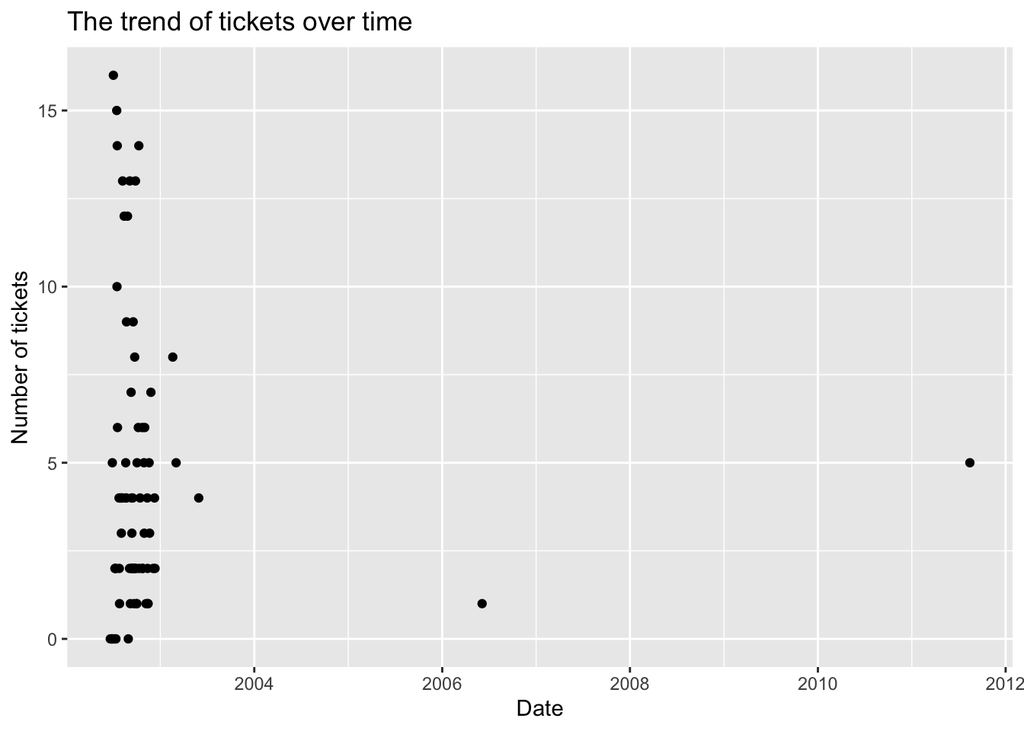

```r
mydata_sort %>%
  select(Date, `Bus Tickets (Number of)`) %>%
  filter(is.na(`Bus Tickets (Number of)`)==F) %>%
  group_by(Date) %>%
  summarise(day_tickets = sum(`Bus Tickets (Number of)`)) %>%
  ggplot(aes(x=Date, y=day_tickets)) +
  geom_point() +
  labs(x='Date', y='Number of tickets', title = "The trend of tickets over time")
```

From the scatter plot we can see that except for the two outliers, the points gathered in the time before 2004. The scatter plot is consistent with the note that the bus tickets service was ended. We are not interested in it any more.

### (2) people that UMD have helped:

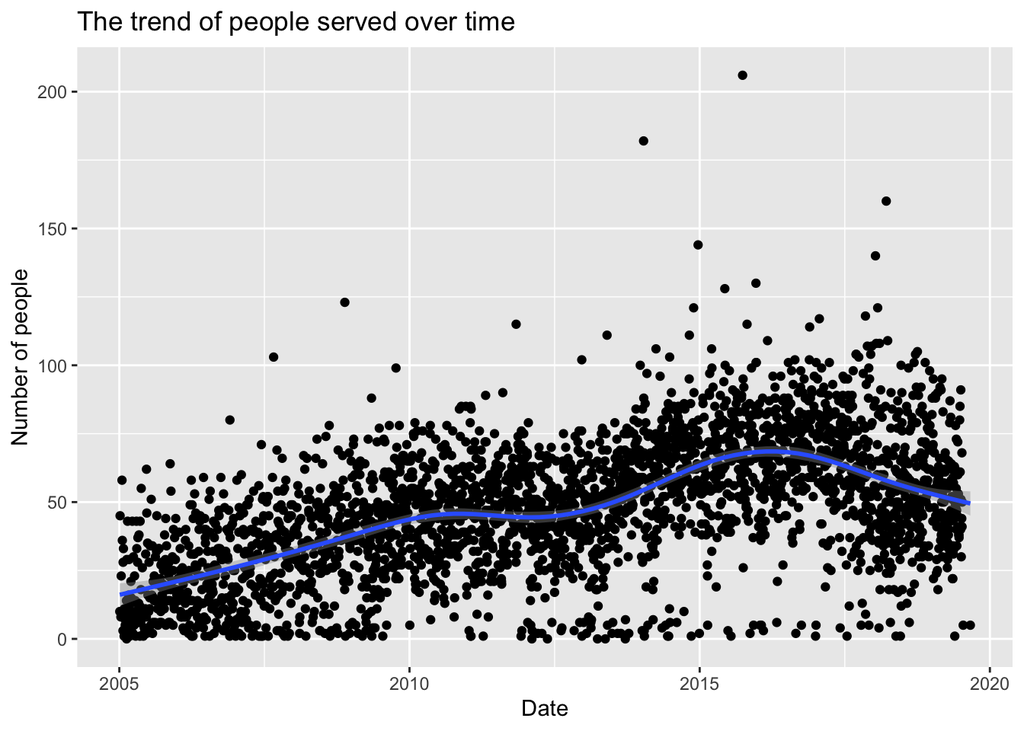

```r
mydata_people = mydata_sort %>%
  select(Date, `Food Provided for`) %>%
  filter(is.na(`Food Provided for`)==F) %>%
  filter(Date <= as.Date("09/11/2019",format = "%m/%d/%Y" )) %>%
  filter(Date >= as.Date("1/1/2005",format = "%m/%d/%Y" )) %>%
  group_by(Date) %>%
  summarise(people_total = sum(`Food Provided for`)) %>%
  filter(people_total < 500)  # remove outliers

ggplot(mydata_people, aes(x=Date, y=people_total)) +
  geom_point() +
  geom_smooth() +
  labs(x='Date', y='Number of people', title = "The trend of people served over time")
```

```r
mean(mydata_people$people_total)
```

```
## [1] 47.81471
```

```r
recent_people = mydata_people %>%
  filter(Date >= as.Date("1/1/2015",format = "%m/%d/%Y" ))
mean(recent_people$people_total)
```

```
## [1] 61.24376
```

From the above plot we could derive that the number of people served was increased before 2016 and decreased after. One possible reason is that more and more people got to know UMD before 2016 and due to their great job, the number of homelessness is decreasing.

To access the average number of people that UMD served per day, we calculate the mean of people server totally (from 2005 till now) and recently (from 2015 till now). The latter number is greater than the former one, which indicates that more people have come for help these years.

### (3) food pounds:

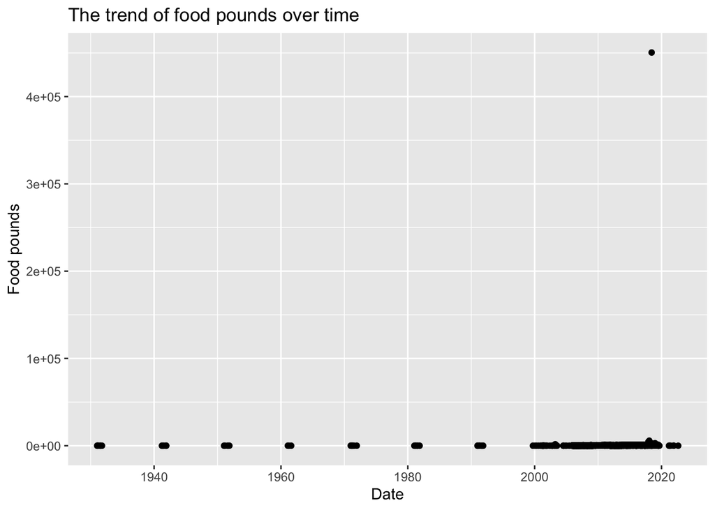

```r
mydata_sort %>%
  select(Date, `Food Pounds`) %>%
  filter(is.na(`Food Pounds`)==F) %>%
  group_by(Date) %>%
  summarise(Food_total = sum(`Food Pounds`)) %>%
  ggplot(aes(x=Date, y=Food_total)) +
  geom_point() +
  labs(x='Date', y='Food pounds', title = "The trend of food pounds over time")
```

From the results we can see that there’s an outlier taking extremly high value which is more than $4 \times 10^5$. It’s most likely a typo since it’s impossible to gave out more than $4 \times 10^5$ pounds food one day. What’s more, we have noticed that there are some values of date which are beyong 2020 (in the future!). Also we are not interested in what happened before 1980s, thus removing those outliers and zooming in the plot after 2000. We have to re-do the scatter plot to gain more information.

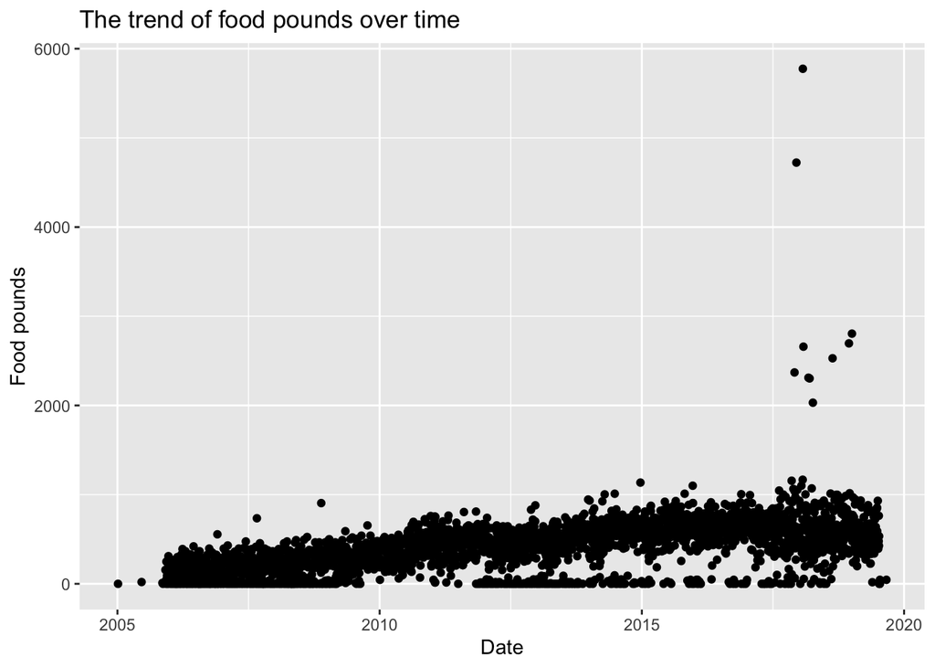

```r
mydata_sort %>%
  select(Date, `Food Pounds`) %>%
  filter(is.na(`Food Pounds`)==F) %>%
  filter(Date <= as.Date("09/11/2019",format = "%m/%d/%Y" )) %>%
  filter(Date >= as.Date("1/1/2005",format = "%m/%d/%Y" )) %>%
  group_by(Date) %>%
  summarise(Food_total = sum(`Food Pounds`)) %>%
  filter(Food_total != max(Food_total)) %>%
  ggplot(aes(x=Date, y=Food_total)) +
  geom_point() +
  labs(x='Date', y='Food pounds', title = "The trend of food pounds over time")
```

We found there are still some high values from the scatter plots. Then we handle with the data from two aspects. For the outliers, we want to know what made it outstanding, thus list all the values which are more than 2000. For the relatively “normal” points, we want to know the tendency.

```r
# list the date of outliers
mydata_sort %>%
  select(Date, `Food Pounds`) %>%
  filter(is.na(`Food Pounds`)==F) %>%
  filter(Date <= as.Date("09/11/2019",format = "%m/%d/%Y" )) %>%
  filter(Date >= as.Date("1/1/2005",format = "%m/%d/%Y" )) %>%
  group_by(Date) %>%
  summarise(Food_total = sum(`Food Pounds`)) %>%
  filter(Food_total != max(Food_total)) %>%
  filter(Food_total >= 2000)
```

```
## # A tibble: 10 x 2
##    Date       Food_total
##    <date>          <dbl>
##  1 2017-11-29       2370
##  2 2017-12-12       4723
##  3 2018-01-26       5775
##  4 2018-01-30       2659
##  5 2018-03-06       2311
##  6 2018-03-14       2303
##  7 2018-04-06       2031
##  8 2018-08-21       2529
##  9 2018-12-13       2696
## 10 2019-01-03       2805
```

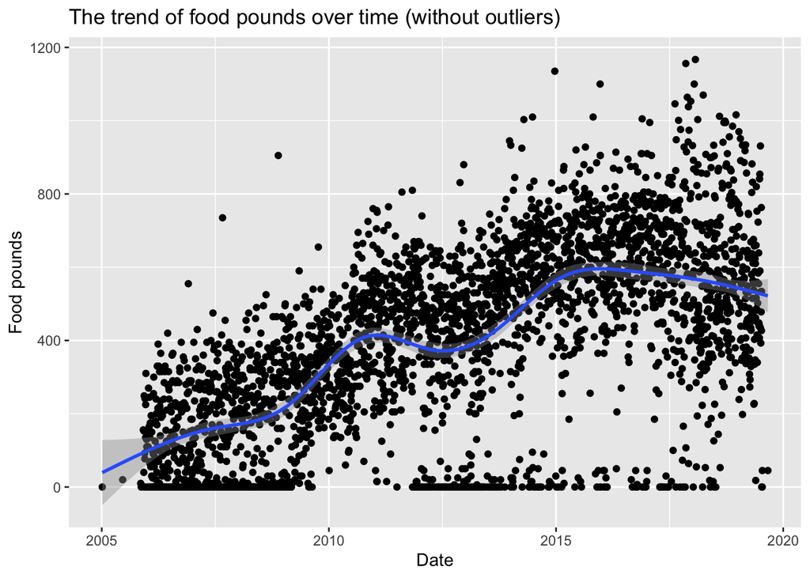

```r
# fit the points with curve
mydata_food = mydata_sort %>%
  select(Date, `Food Pounds`) %>%
  filter(is.na(`Food Pounds`)==F) %>%
  filter(Date <= as.Date("09/11/2019",format = "%m/%d/%Y" )) %>%
  filter(Date >= as.Date("1/1/2005",format = "%m/%d/%Y" )) %>%
  group_by(Date) %>%
  summarise(Food_total = sum(`Food Pounds`)) %>%
  filter(Food_total != max(Food_total)) %>%
  filter(Food_total < 2000)

ggplot(mydata_food,aes(x=Date, y=Food_total)) +
  geom_point() +
  geom_smooth() +
  labs(x='Date', y='Food pounds', title = "The trend of food pounds over time (without outliers)")
```

```r
mean(mydata_food$Food_total)
```

```
## [1] 403.6863
```

```r
recent_food = mydata_food %>%
  filter(Date >= as.Date("1/1/2015",format = "%m/%d/%Y" ))
mean(recent_food$Food_total)
```

```
## [1] 569.5581
```

For the dates listed above, we don’t know exactly what happened on those days, thus we don’t know whether they were produced because of a typo or because the days were special (any catastrophes which we didn’t find any references or the promotion days of UMD).

From the scatter plot, we can see the needs of the amount of food basically increased before 2015 and slightly decreased after 2015. I think one possible explanation is that UMD routinely documented the data after 2005 (from which the points became dense) and more people came for help as UMD promoted their service. Due to the excellent job that UMD did, the amount food to help people in need has been decreasing after 2015, which means the situation of homeless people is getting better and better. The two numbers showed the food pounds they provided per day from 2005 till now and from 2015 till now.

### (4) clothing items:

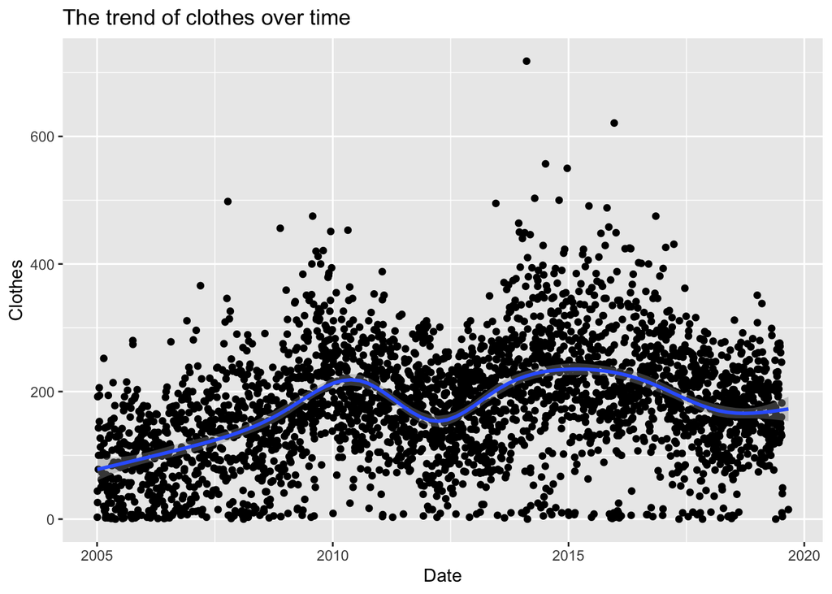

```r
mydata_cloth = mydata_sort %>%
  select(Date, `Clothing Items`) %>%
  filter(is.na(`Clothing Items`)==F) %>%
  filter(Date <= as.Date("09/11/2019",format = "%m/%d/%Y" )) %>%
  filter(Date >= as.Date("1/1/2005",format = "%m/%d/%Y" )) %>%
  group_by(Date) %>%
  summarise(cloth_total = sum(`Clothing Items`))

ggplot(mydata_cloth, aes(x=Date, y=cloth_total)) +
  geom_point() +
  geom_smooth() +
  labs(x='Date', y='Clothes', title = "The trend of clothes over time")
```

```r
mean(mydata_cloth$cloth_total)
```

```
## [1] 178.1044
```

```r
recent_cloth = mydata_cloth %>%
  filter(Date >= as.Date("1/1/2015",format = "%m/%d/%Y" ))
mean(recent_cloth$cloth_total)
```

```
## [1] 195.3042
```

We did the same thing for clothing items as for food pounds. It showed that the change of clothing items was roughly the same as that of food pounds which increased before 2010, fluctuated between 2010-2015 and then decreased after 2015. But the intensity is was not as high as that of food pounds. It supported my opinion brought up before. The two numbers showed the cloth items they provided per day from 2005 till now and from 2015 till now.

We have also plotted the change over time for diapers, school kits, hygiene kits and financial supports which are in the Appendix. From the scatter plots, we could see that foods and clothes have most observations, which indicated that these two are the most needed. It’s consistent with the commen sense that they were for basic life.

## 2. Find

### (1) whom have contributed to UMD financially:

```r
mydata_sort %>%
  arrange(`Payer of Support`) %>%
  filter(is.na(`Payer of Support`)==F) %>%
  # case insensitive
  group_by(Category = stringi::stri_trans_totitle(`Payer of Support`)) %>%
  summarise(n = n())
```

```
## # A tibble: 97 x 2
##    Category                                                               n
##    <chr>                                                              <int>
##  1 $300 Good Neighbor Fund                                                1
##  2 $40 Mt. Sylvan; $125.74 St Phillips Episcopal                          1
##  3 $50 St. Philips; $280.96 Good Neighbor Fund                            1
##  4 $50.00 St. Philip's; $104.00 Trinity; $100.00 Mcmannen                 1
##  5 Aldersgateumc-$100; St. Matthew Catholic-$100; Mt.sylvanumc-$40;C…     1
##  6 Anonymous--$20                                                         1
##  7 Asbury Temple Umc                                                      2
##  8 Asbury Umc                                                             3
##  9 Bethany Umc                                                            2
## 10 Calvary Umc                                                            3
## # … with 87 more rows
```

We could thank thoes people/organizations who have donated money to support UMD and people in need.

### (2) what type of bills people have to pay:

```r
mydata_sort %>%
  arrange(`Type of Bill Paid`) %>%
  filter(is.na(`Type of Bill Paid`)==F) %>%
  # case insensitive
  group_by(Category = stringi::stri_trans_totitle(`Type of Bill Paid`)) %>%
  summarise(n = n())
```

```
## # A tibble: 108 x 2
##    Category                                               n
##    <chr>                                              <int>
##  1 2 Greyhound Tickets To Tn; Prescription Assistance     1
##  2 Apartment Deposit                                      1
##  3 Apartment Security Deposit                             1
##  4 Birth Certificate                                      3
##  5 Birth Certificate Fee                                  1
##  6 Birth Certificates                                     1
##  7 Bus Fare To Naples, Fl                                 1
##  8 Bus Fare To South Boston, Va                           1
##  9 Bus Fare, One Way To Winston-Salem                     1
## 10 Bus Ticket                                             6
## # … with 98 more rows
```

Though we have apply the case insensitive condition, the data is still a little bit messy since there are different expressions of the same thing, for example, “Greyhound”, “Bus fare”, “one way bus ticket”, etc., all represents bus tickets. But the table is still useful for references.

## 3. Show the potential relationships between different variables.

### Food pounds V.S. Food Provided for:

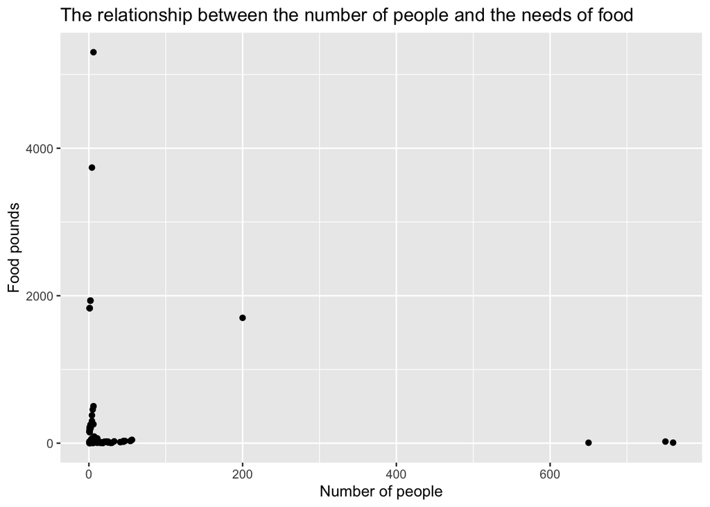

```r
mydata_sort %>%
  filter(`Food Provided for` > 0) %>%
  filter(`Food Pounds` > 0 ) %>%
  filter(`Food Pounds` != max(`Food Pounds`)) %>%
  ggplot(aes(x=`Food Provided for`,y=`Food Pounds`)) +
  geom_point() +
  labs(x='Number of people', y='Food pounds', title = "The relationship between the number of people and the needs of food")
```

Remove all the single points which were likely to be typoes.

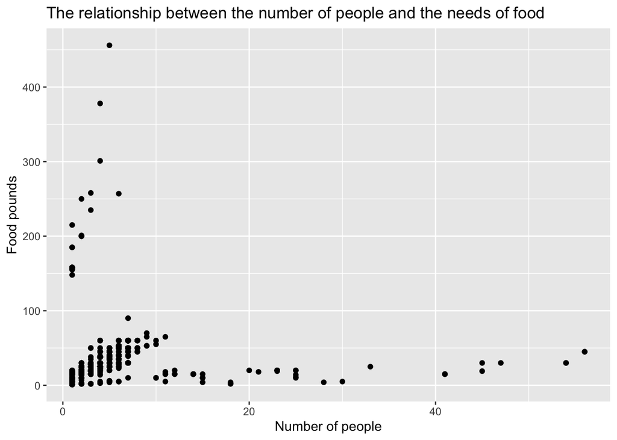

```r
mydata_sort %>%
  filter(`Food Provided for` > 0 & `Food Provided for` < 200) %>%
  filter(`Food Pounds` > 0 & `Food Pounds` < 1000) %>%
  filter(`Food Pounds` != max(`Food Pounds`)) %>%
  ggplot(aes(x=`Food Provided for`,y=`Food Pounds`)) +
  geom_point() +
  labs(x='Number of people', y='Food pounds', title = "The relationship between the number of people and the needs of food")
```

From the scatter points we can see that the two variables are positively related with each other. For most people, the increasing ratio of the two variables is roughly the same (refer to all the gathering points in the left downside corner). But there are two different patterns when the number of “food provided for” and the number of “food pounds” increased. Maybe some people wanted to get more food at a time to save for future needs, so that they can come less often. A possible reason for another pattern is people wanted to get less food at a time but came more often.

#### Average pounds of food per person per visit.

We then care about the average pounds of food that one person needs at a time.

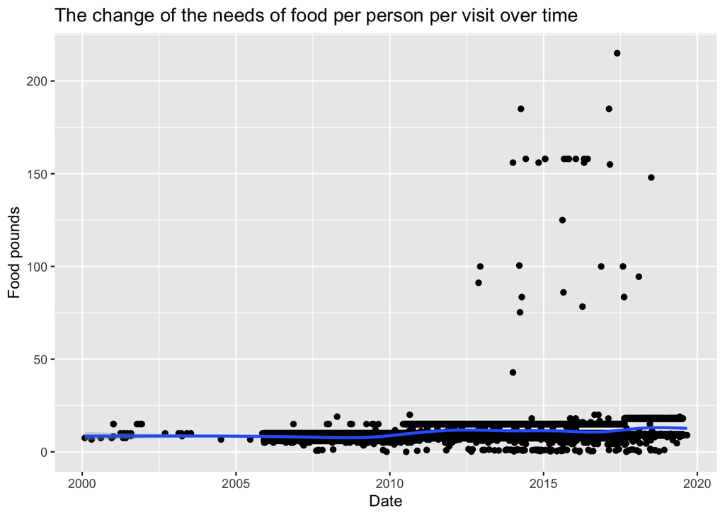

```r
averg_food = mydata_sort %>%
  select(Date,`Food Pounds`,`Food Provided for`) %>%
  filter(`Food Provided for` > 0 ) %>%
  filter(`Food Pounds` > 0 ) %>%
  filter(`Food Pounds` != max(`Food Pounds`)) %>%
  mutate(mean_food = `Food Pounds`/`Food Provided for`) %>%
  filter(mean_food < 500) %>%
  filter(Date > as.Date("1/1/2000",format = "%m/%d/%Y" )) %>%
  filter(Date < as.Date("9/11/2019",format = "%m/%d/%Y" ))
ggplot(averg_food, aes(Date,mean_food,)) +
  geom_point() +
  geom_smooth() +
  labs(x='Date', y='Food pounds', title = "The change of the needs of food per person per visit over time")
```

```r
mean(averg_food$mean_food)
```

```
## [1] 10.86818
```

```r
recent_avgfood = averg_food %>%
  filter(Date >= as.Date("1/1/2015",format = "%m/%d/%Y" ))
mean(recent_avgfood$mean_food)
```

```
## [1] 11.85719
```

From the plot above we know, though there are quite a few outliers, most people came to get roughtly the same average pounds of food for one person (~10 pounds). This information is useful to UMD for future preparation of food.

### Clothing Items V.S. Food Provided for:

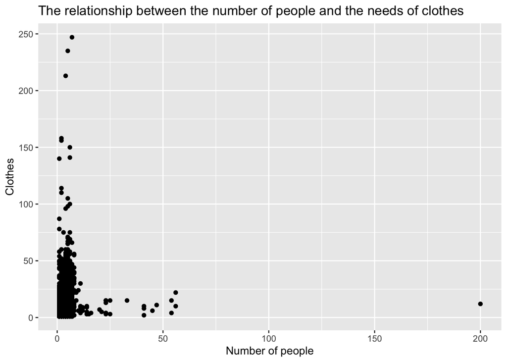

```r
mydata_sort %>%
  filter(`Clothing Items` > 0) %>%
  filter(`Food Provided for` > 0 ) %>%
  ggplot(aes(x=`Food Provided for`,y=`Clothing Items`)) +
  geom_point() +
  labs(x='Number of people', y='Clothes', title = "The relationship between the number of people and the needs of clothes")
```

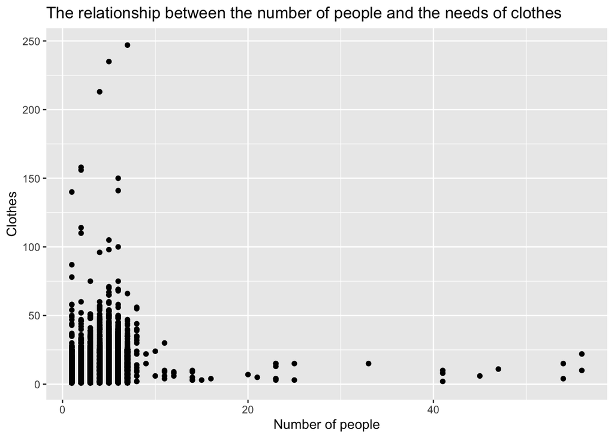

```r
mydata_sort %>%
  filter(`Clothing Items` > 0) %>%
  filter(`Food Provided for` > 0 & `Food Provided for` < 100) %>%
  ggplot(aes(x=`Food Provided for`,y=`Clothing Items`)) +
  geom_point() +
  labs(x='Number of people', y='Clothes', title = "The relationship between the number of people and the needs of clothes")
```

This plot didn’t show the quite the same as the previous one, especially in the gathering zone. It seems that there’s not a strong relationship between “Clothing items” and “Food Provided for” since different people may have different needs for clothes.

#### Average items of clothing per person per visit.

Similarly, we want to know the average items of clothes that one person needs at a time.

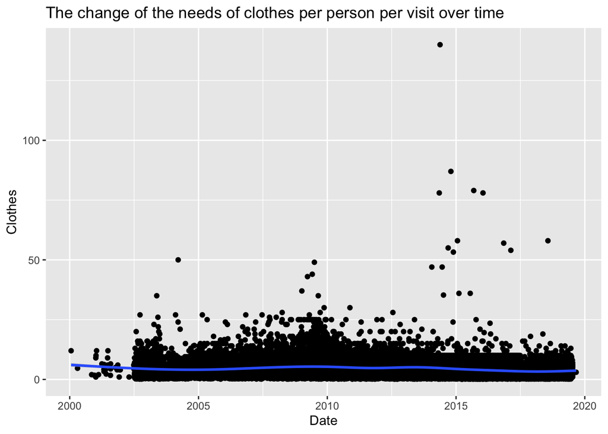

```r
averg_clothes = mydata_sort %>%
  select(Date,`Clothing Items`,`Food Provided for`) %>%
  filter(`Food Provided for` > 0 & `Food Provided for` < 100) %>%
  filter(`Clothing Items` > 0 ) %>%
  mutate(mean_clothes = `Clothing Items`/`Food Provided for`) %>%
  filter(Date > as.Date("1/1/2000",format = "%m/%d/%Y" )) %>%
  filter(Date < as.Date("9/11/2019",format = "%m/%d/%Y" ))

ggplot(averg_clothes, aes(Date,mean_clothes,)) +
  geom_point() +
  geom_smooth() +
  labs(x='Date', y='Clothes', title = "The change of the needs of clothes per person per visit over time")
```

```r
mean(averg_clothes$mean_clothes)
```

```
## [1] 4.35684
```

```r
recent_avgclothes = averg_clothes %>%
  filter(Date >= as.Date("1/1/2015",format = "%m/%d/%Y" ))
mean(recent_avgclothes$mean_clothes)
```

```
## [1] 3.631419
```

Similarly as the analysis for “Food pounds” variable, most people came to get roughtly the same average items of clothes for one person (~4 items). This information is useful to UMD for future preparation of clothing items.

## 4. People (family) coming most frequently and examples of some specific families.

### Who came most often.

First we group the data by client file number which is the ID of every family. Then summarise the count of every family and sort by decreasing order. Then we could get the results below.

```r
mydata_sort %>%
  group_by(`Client File Number`) %>%
  summarise(n = n()) %>%
  arrange(desc(n))
```

```
## # A tibble: 15,352 x 2
##    `Client File Number`     n
##                   <dbl> <int>
##  1                 3502   249
##  2                  805   193
##  3                  738   170
##  4                 1176   160
##  5                  904   146
##  6                  255   139
##  7                 4098   134
##  8                 5228   134
##  9                 2399   133
## 10                  188   131
## # … with 15,342 more rows
```

Take client 3502 and 805 as examples.

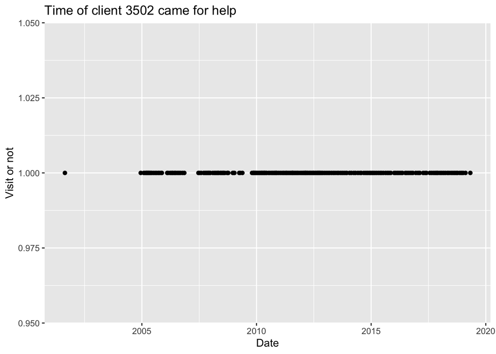

```r
client3502 = mydata_sort %>%
  filter(`Client File Number`==3502) %>%
  arrange(Date)
ggplot(client3502, aes(x=Date,y=1)) +
  geom_point() +
  labs(x='Date', y='Visit or not', title = "Time of client 3502 came for help")
```

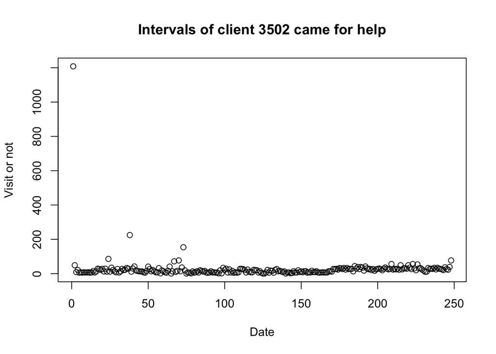

```r
client3502_interval = client3502$Date[-1] - client3502$Date[-length(client3502$Date)]
plot(x=1:length(client3502_interval), y=client3502_interval, xlab='Date', ylab='Visit or not', main="Intervals of client 3502 came for help")
```

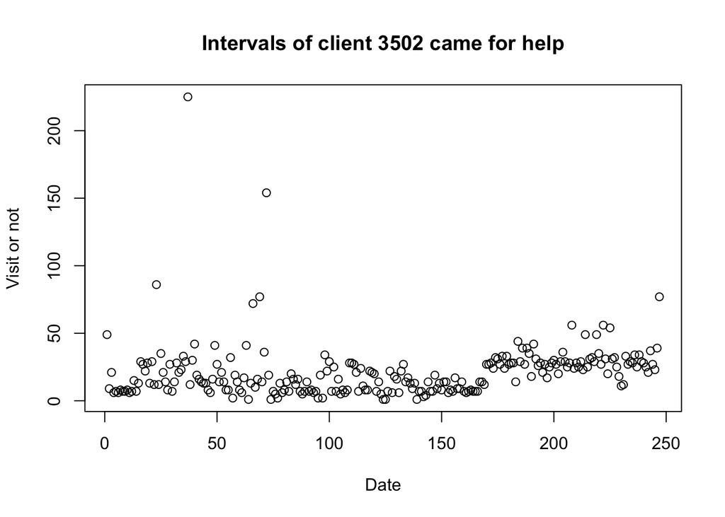

```r
# remove the first point which was an outlier
plot(x=1:(length(client3502_interval)-1), y=client3502_interval[-1],xlab='Date', ylab='Visit or not', main="Intervals of client 3502 came for help")
```

```r
mean(client3502_interval[-1])
```

```
## Time difference of 21.25506 days
```

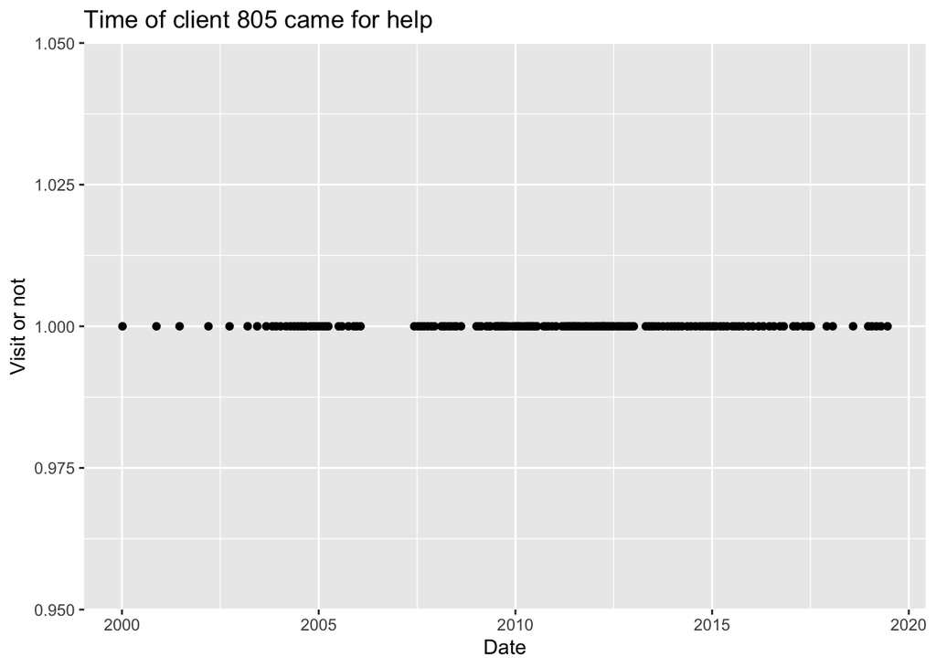

```r
client805 = mydata_sort %>%
  filter(`Client File Number`==805) %>%
  filter(Date >= as.Date("1/1/2000",format = "%m/%d/%Y" )) %>%
  arrange(Date)
ggplot(client805, aes(x=Date,y=1)) +
  geom_point() +
  labs(x='Date', y='Visit or not', title = "Time of client 805 came for help")
```

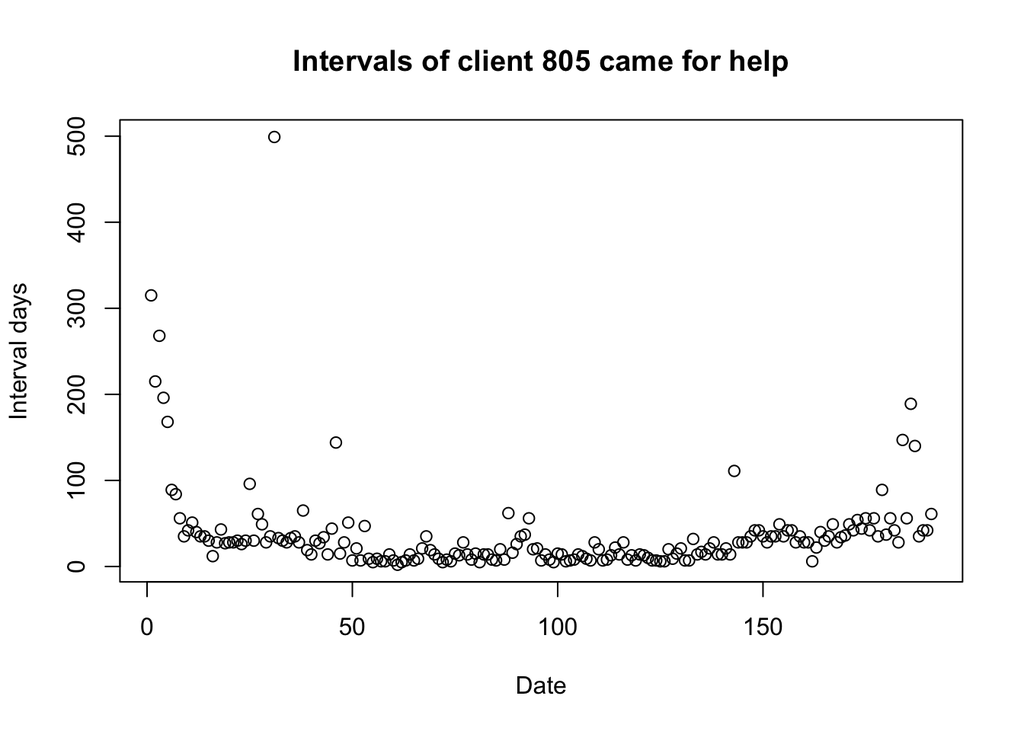

```r
client805_interval = client805$Date[-1] - client805$Date[-length(client805$Date)]
plot(x=1:(length(client805_interval)), y=client805_interval, xlab='Date', ylab='Interval days', main="Intervals of client 805 came for help")
```

```r
mean(client805_interval)
```

```
## Time difference of 37.18848 days
```

They both have come since more than 10 years ago. It suggests that they have been going through a hard time for really long and they may need further help. Client 3502 needs more help than client 805 since the first one came more frequently and the average interval is shorter.

### Who came most recently.

```r
mydata_sort %>%
  arrange(desc(Date)) %>%
  filter(Date <= as.Date("09/11/2019",format = "%m/%d/%Y" ))
```

```
## # A tibble: 79,831 x 18
##    Date       `Client File Nu… `Client File Me… `Bus Tickets (N…
##    <date>                <dbl>            <dbl>            <dbl>
##  1 2019-08-31            14422                0               NA
##  2 2019-07-17              814                0               NA
##  3 2019-07-17            12488                0               NA
##  4 2019-07-17            14087                0               NA
##  5 2019-07-17            15248                0               NA
##  6 2019-07-17            16605                0               NA
##  7 2019-07-17            16614                0               NA
##  8 2019-07-17            16697                0               NA
##  9 2019-07-17            16747                0               NA
## 10 2019-07-17            16780                0               NA
## # … with 79,821 more rows, and 14 more variables: `Notes of
## #   Service` <chr>, `Food Provided for` <dbl>, `Food Pounds` <dbl>,
## #   `Clothing Items` <dbl>, Diapers <dbl>, `School Kits` <dbl>, `Hygiene
## #   Kits` <dbl>, Referrals <chr>, `Financial Support` <dbl>, `Type of Bill
## #   Paid` <chr>, `Payer of Support` <chr>, Field1 <lgl>, Field2 <lgl>,
## #   Field3 <lgl>
```

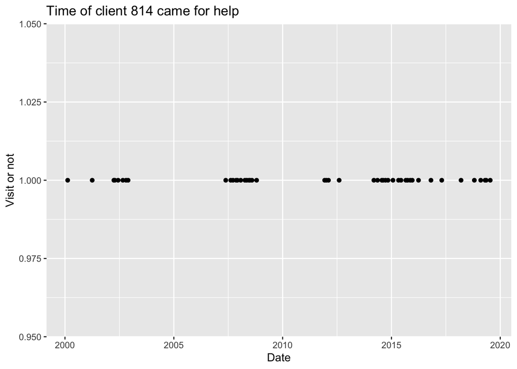

```r
client814 = mydata_sort %>%
  filter(`Client File Number`==814) %>%
  arrange(Date)
ggplot(client814, aes(x=Date,y=1)) +
  geom_point() +
  labs(x='Date', y='Visit or not', title = "Time of client 814 came for help")
```

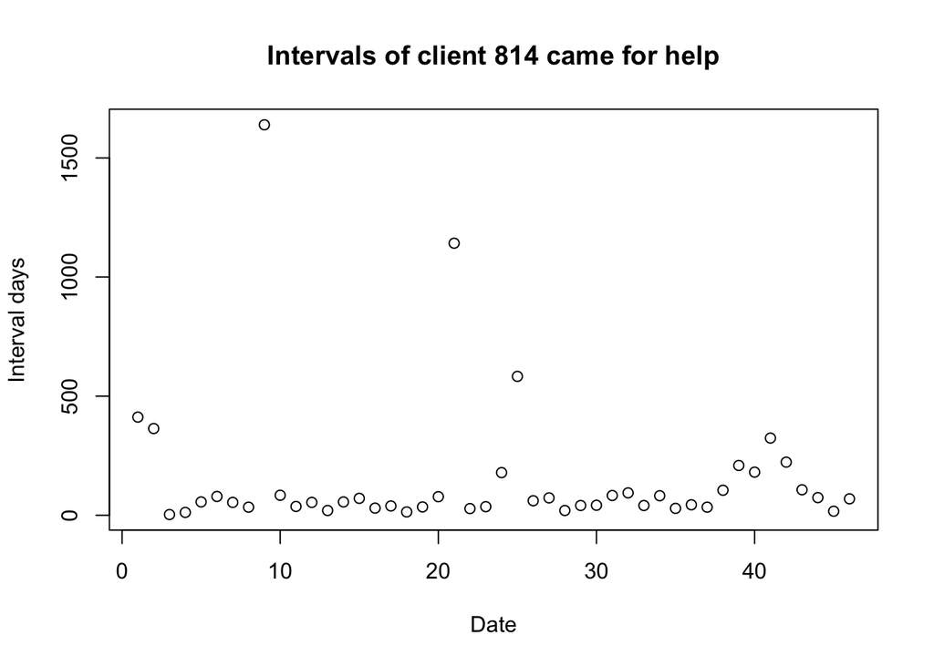

```r
client814_interval = client814$Date[-1] - client814$Date[-length(client814$Date)]
plot(x=1:(length(client814_interval)), y=client814_interval, xlab='Date', ylab='Interval days', main="Intervals of client 814 came for help")
```

```r
mean(client814_interval)
```

```
## Time difference of 154.1739 days
```

From the plot we can see that this client came frequently in small periods of time which were occasionally took place with relatviely long intervals. According to the mean interval, he/she was not so struggling as Client 3502 and client 805. But it seems that his/her life is becoming worse since the length of the interval is becoming shorter. From these examples, we can show the specific situation of every person/family to give them specific care.

# Conclusion

# Appendix

## Show the change over time for

### (5) diapers:

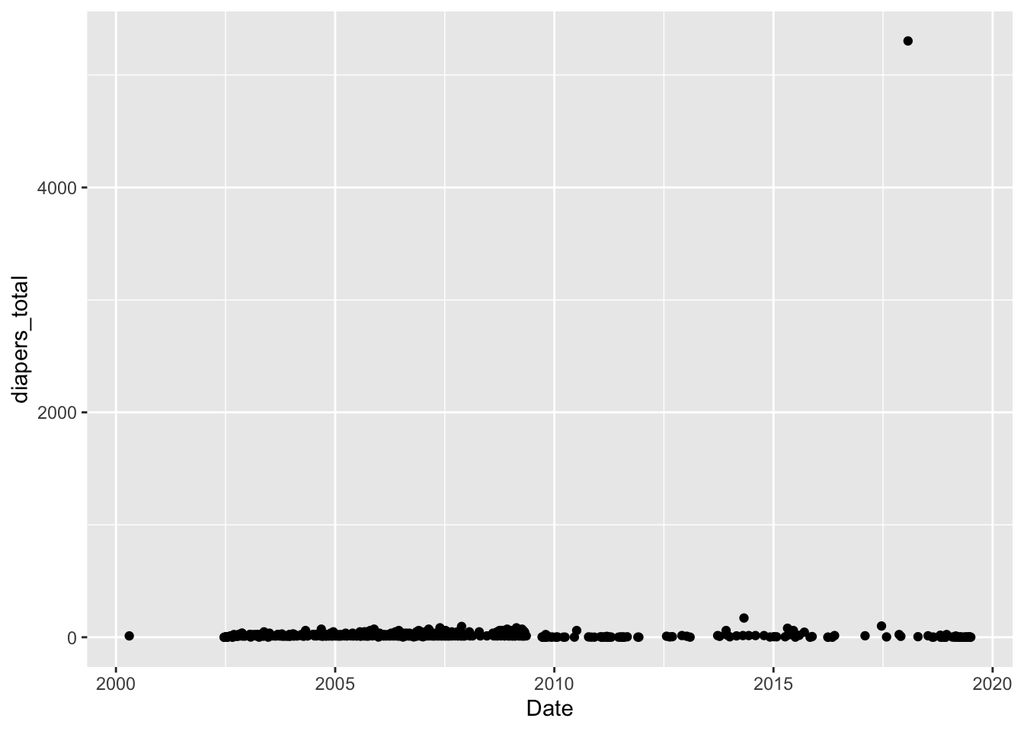

```r
mydata_sort %>%
  select(Date, Diapers) %>%
  filter(is.na(Diapers)==F) %>%
  group_by(Date) %>%
  summarise(diapers_total = sum(Diapers)) %>%
  ggplot(aes(x=Date, y=diapers_total)) +
  geom_point()
```

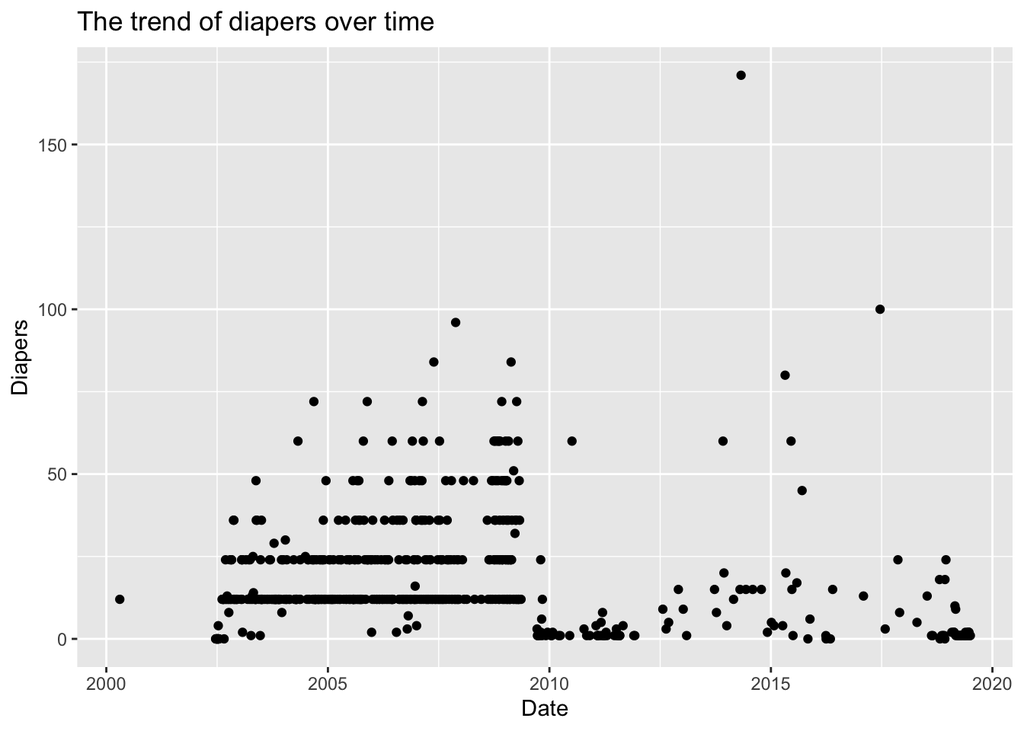

```r
# remove outliers
mydata_sort %>%
  select(Date, Diapers) %>%
  filter(is.na(Diapers)==F) %>%
  group_by(Date) %>%
  summarise(diapers_total = sum(Diapers)) %>%
  filter(diapers_total != max(diapers_total)) %>%
  ggplot(aes(x=Date, y=diapers_total)) +
  geom_point() +
  labs(x='Date', y='Diapers', title = "The trend of diapers over time")
```

### (6) school kits:

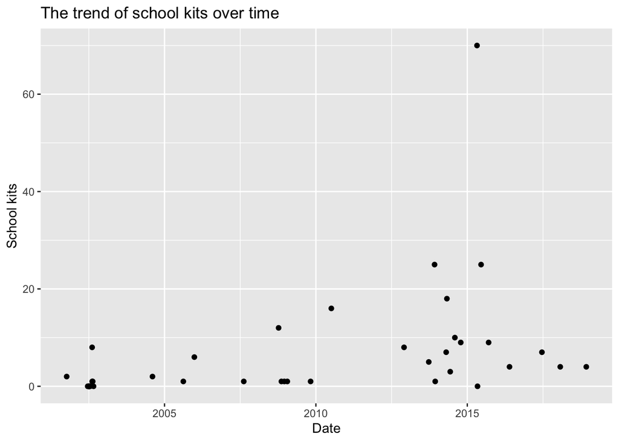

```r
mydata_sort %>%
  select(Date, `School Kits`) %>%
  filter(is.na(`School Kits`)==F) %>%
  group_by(Date) %>%
  summarise(school_total = sum(`School Kits`)) %>%
  ggplot(aes(x=Date, y=school_total)) +
  geom_point() +
  labs(x='Date', y='School kits', title = "The trend of school kits over time")
```

### (7) hygiene kits:

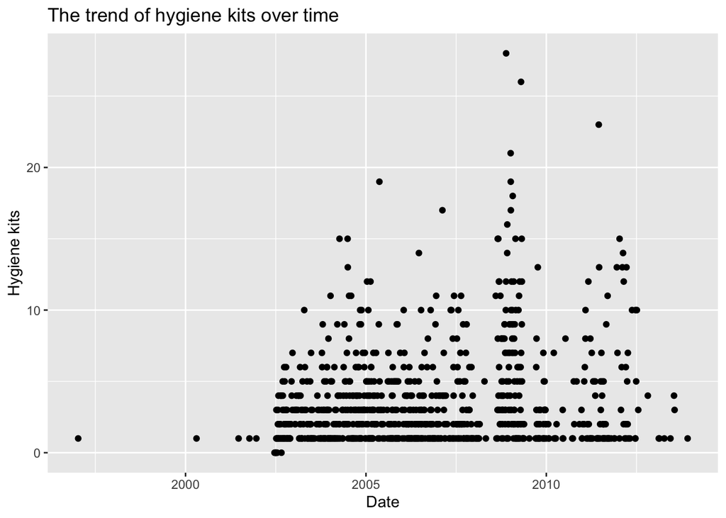

```r
mydata_sort %>%
  select(Date, `Hygiene Kits`) %>%
  filter(is.na(`Hygiene Kits`)==F) %>%
  group_by(Date) %>%
  summarise(hygiene_total = sum(`Hygiene Kits`)) %>%
  ggplot(aes(x=Date, y=hygiene_total)) +
  geom_point() +
  labs(x='Date', y='Hygiene kits', title = "The trend of hygiene kits over time")
```

(5)-(7) shows the change over time for diapers, school kits and hygiene kits which were in lower needs than foods and clothes. Thus these three variables could not represent the whole population of people in need. We are no longer interested in this.

### (8) financial support:

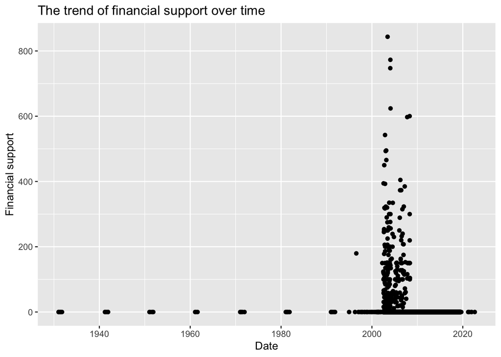

```r
mydata_sort %>%
  select(Date, `Financial Support`) %>%
  filter(is.na(`Financial Support`)==F) %>%
  group_by(Date) %>%
  summarise(finance_total = sum(`Financial Support`)) %>%
  ggplot(aes(x=Date, y=finance_total)) +
  geom_point() +
  labs(x='Date', y='Financial support', title = "The trend of financial support over time")
```

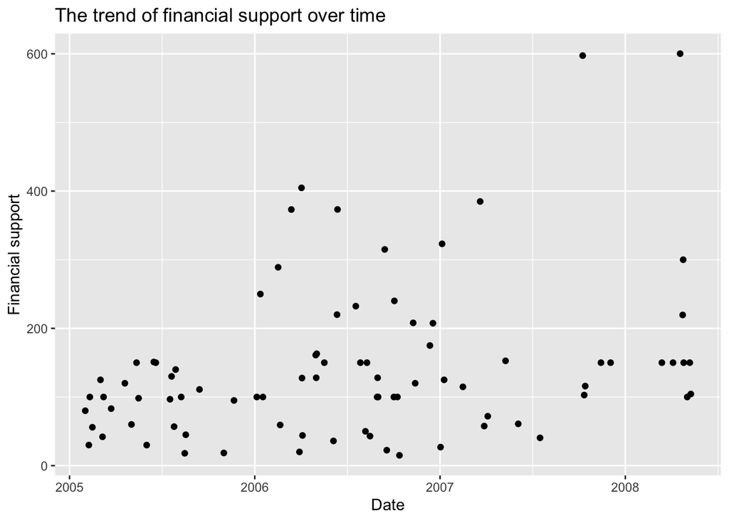

```r
mydata_sort %>%
  select(Date, `Financial Support`) %>%
  filter(is.na(`Financial Support`)==F) %>%
  filter(Date <= as.Date("09/11/2019",format = "%m/%d/%Y" )) %>%
  filter(Date >= as.Date("1/1/2005",format = "%m/%d/%Y" )) %>%
  group_by(Date) %>%
  summarise(finance_total = sum(`Financial Support`)) %>%
  filter(finance_total!=0) %>%
  ggplot(aes(x=Date, y=finance_total)) +
  geom_point() +
  labs(x='Date', y='Financial support', title = "The trend of financial support over time")
```

Since financial support was discontinued which is also indicated from the plot above, we won’t waste much time on it.